# **Analysis of longitudinal data**

### **1. Graphical displays and summary measure approach**

### **1.1. Structure of the longitudinal RATSL data**

The original data is a nutrition study conducted in three groups of rats, three groups were put on different diets and each rat’s body weight was recorded repeatedly over a 9-week.

RATSL longitudinal data has 176 observations (rows) and 5 variables (columns). The variables are ID (1-16), Group (1, 2 or 3), WD (WD1-WD64), Weight (weight in grams) and Time (1-64). Each rat has several rows of information, one row has information of one weight measurement in one time point. The Time variable includes the day number when the body weight measurement was done. The ID and Group variable are changed to factor variables.

```r
# week 6: analysis, Graphical Displays and Summary Measure Approach
date()
```

```
## [1] "Mon Dec 13 08:46:32 2021"
```

```r
# access the packages dplyr and tidyr
library(dplyr)
```

```r
library(tidyr)
# access the package ggplot2
library(ggplot2)

# read in RATSL data
RATSL <- read.csv('~/IODS-project/data/RATSL.csv')

# check the data
glimpse(RATSL)
```

```
## Rows: 176
## Columns: 5
## $ ID     <int> 1, 2, 3, 4, 5, 6, 7, 8, 9, 10, 11, 12, 13, 14, 15, 16, 1, 2, 3,…
## $ Group  <int> 1, 1, 1, 1, 1, 1, 1, 1, 2, 2, 2, 2, 3, 3, 3, 3, 1, 1, 1, 1, 1, …
## $ WD     <chr> "WD1", "WD1", "WD1", "WD1", "WD1", "WD1", "WD1", "WD1", "WD1", …
## $ Weight <int> 240, 225, 245, 260, 255, 260, 275, 245, 410, 405, 445, 555, 470…
## $ Time   <int> 1, 1, 1, 1, 1, 1, 1, 1, 1, 1, 1, 1, 1, 1, 1, 1, 8, 8, 8, 8, 8, …
```

```r
# factor variables ID and Group (convert the categorical variables to factors) of RATS data
RATSL$ID <- factor(RATSL$ID)
RATSL$Group <- factor(RATSL$Group)

# check the data
glimpse(RATSL)
```

```
## Rows: 176
## Columns: 5
## $ ID     <fct> 1, 2, 3, 4, 5, 6, 7, 8, 9, 10, 11, 12, 13, 14, 15, 16, 1, 2, 3,…
## $ Group  <fct> 1, 1, 1, 1, 1, 1, 1, 1, 2, 2, 2, 2, 3, 3, 3, 3, 1, 1, 1, 1, 1, …
## $ WD     <chr> "WD1", "WD1", "WD1", "WD1", "WD1", "WD1", "WD1", "WD1", "WD1", …
## $ Weight <int> 240, 225, 245, 260, 255, 260, 275, 245, 410, 405, 445, 555, 470…
## $ Time   <int> 1, 1, 1, 1, 1, 1, 1, 1, 1, 1, 1, 1, 1, 1, 1, 1, 8, 8, 8, 8, 8, …
```

```r
head(RATSL)
```

```
##   ID Group  WD Weight Time
## 1  1     1 WD1    240    1
## 2  2     1 WD1    225    1
## 3  3     1 WD1    245    1
## 4  4     1 WD1    260    1
## 5  5     1 WD1    255    1
## 6  6     1 WD1    260    1
```

### **1.2. Graphical displays**

Let’s visualize graphically the RATSL data, differentiating the three diet groups.

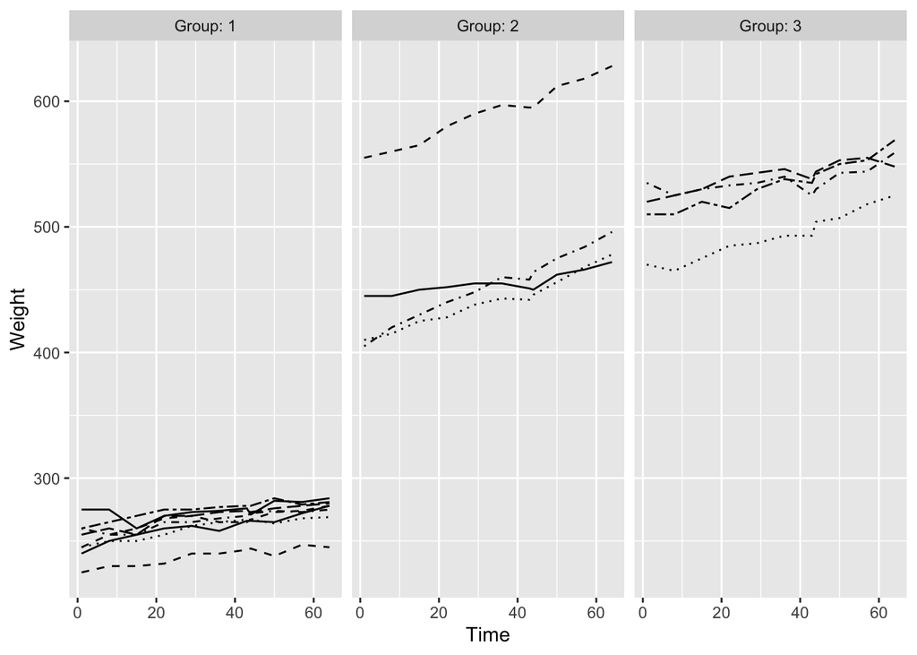

```r
# draw the plot
ggplot(RATSL, aes(x = Time, y = Weight, linetype = ID)) +
  geom_line() +
  scale_linetype_manual(values = rep(1:10, times=4)) +
  facet_grid(. ~ Group, labeller = label_both) +
  theme(legend.position = "none") +
  scale_y_continuous(limits = c(min(RATSL$Weight), max(RATSL$Weight)))
```

```r
# standardize the variable Weight
RATSL <- RATSL %>%
  group_by(Time) %>%
  mutate(stdweight = (Weight - mean(Weight))/sd(Weight) ) %>%
  ungroup()

# glimpse the data
glimpse(RATSL)
```

```
## Rows: 176
## Columns: 6
## $ ID        <fct> 1, 2, 3, 4, 5, 6, 7, 8, 9, 10, 11, 12, 13, 14, 15, 16, 1, 2,…
## $ Group     <fct> 1, 1, 1, 1, 1, 1, 1, 1, 2, 2, 2, 2, 3, 3, 3, 3, 1, 1, 1, 1, …
## $ WD        <chr> "WD1", "WD1", "WD1", "WD1", "WD1", "WD1", "WD1", "WD1", "WD1…
## $ Weight    <int> 240, 225, 245, 260, 255, 260, 275, 245, 410, 405, 445, 555, …
## $ Time      <int> 1, 1, 1, 1, 1, 1, 1, 1, 1, 1, 1, 1, 1, 1, 1, 1, 8, 8, 8, 8, …
## $ stdweight <dbl> -1.0011429, -1.1203857, -0.9613953, -0.8421525, -0.8819001, …
```

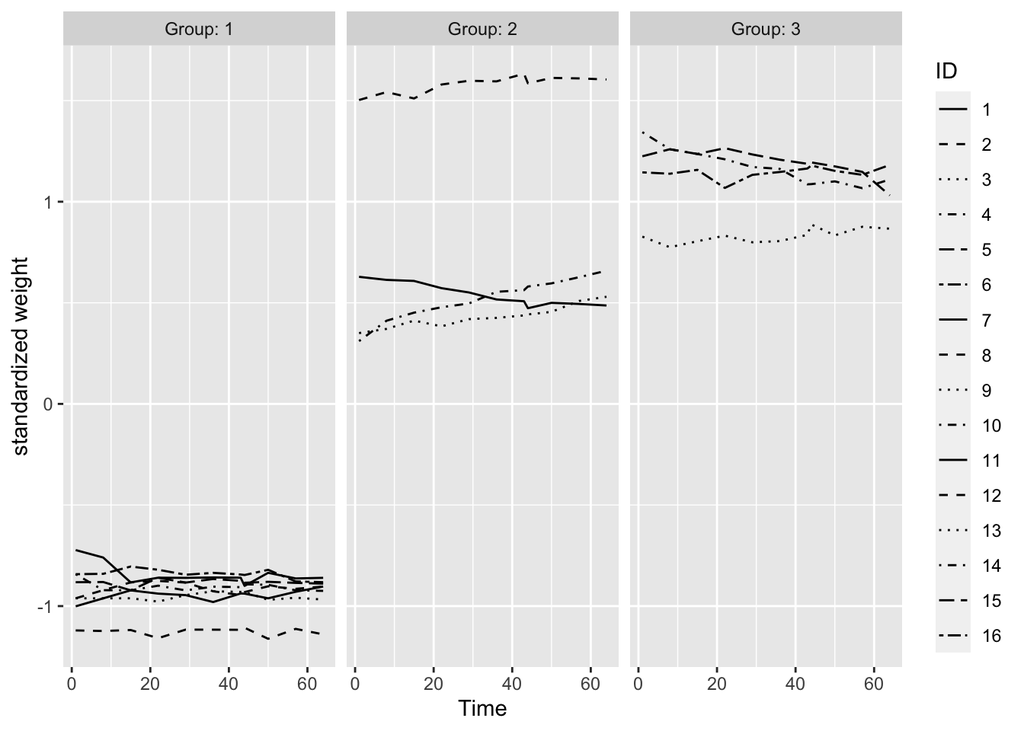

```r
# plot again with the standardized Weight
ggplot(RATSL, aes(x = Time, y = stdweight, linetype = ID)) +
  geom_line() +
  scale_linetype_manual(values = rep(1:10, times=4)) +
  facet_grid(. ~ Group, labeller = label_both) +
  scale_y_continuous(name = "standardized weight")
```

**In the first plot** it seems that the weight increases, especially in groups 2 and 3. Also the rats that have higher weight at the beginning tend to have higher weight throughout the study, especially group 2 and 3 rats are heavier than group 1 rats at the start and throughout the study. This phenomenon is called tracking.

**In the second plot** we can see the individual profiles for weight after standardization. With standardizing we want to look at the tracking phenomenon. The standardized values of each observations are the values obtained by subtracting the relevant occasion mean from the original observation and then dividing by the corresponding visit standard deviation. With the standardized weight values the increase of weight for different diet groups is not seen.

There’s 8 rats in group 1, 4 rats in group 2 and 4 rats in group 3. In each group we can see one rat which weight profile distincts from other rats in the same group.

### **1.3. Summary measure analysis**

Let’s produce a graph showing average (mean) profiles for each diet group along with indication of the variation of the observations at each time point, in this case the standard error of the mean.

```r
# number of days
n <- RATSL$Time %>% unique() %>% length()

# summary data with mean and standard error of weight by group and day
RATSLS <- RATSL %>%
  group_by(Group, Time) %>%
  summarise( mean = mean(Weight), se = sd(Weight)/sqrt(n) ) %>%
  ungroup()
# glimpse the data
glimpse(RATSLS)
```

```
## Rows: 33
## Columns: 4
## $ Group <fct> 1, 1, 1, 1, 1, 1, 1, 1, 1, 1, 1, 2, 2, 2, 2, 2, 2, 2, 2, 2, 2, 2…
## $ Time  <int> 1, 8, 15, 22, 29, 36, 43, 44, 50, 57, 64, 1, 8, 15, 22, 29, 36, …
## $ mean  <dbl> 250.625, 255.000, 254.375, 261.875, 264.625, 265.000, 267.375, 2…
## $ se    <dbl> 4.589478, 3.947710, 3.460116, 4.100800, 3.333956, 3.552939, 3.30…
```

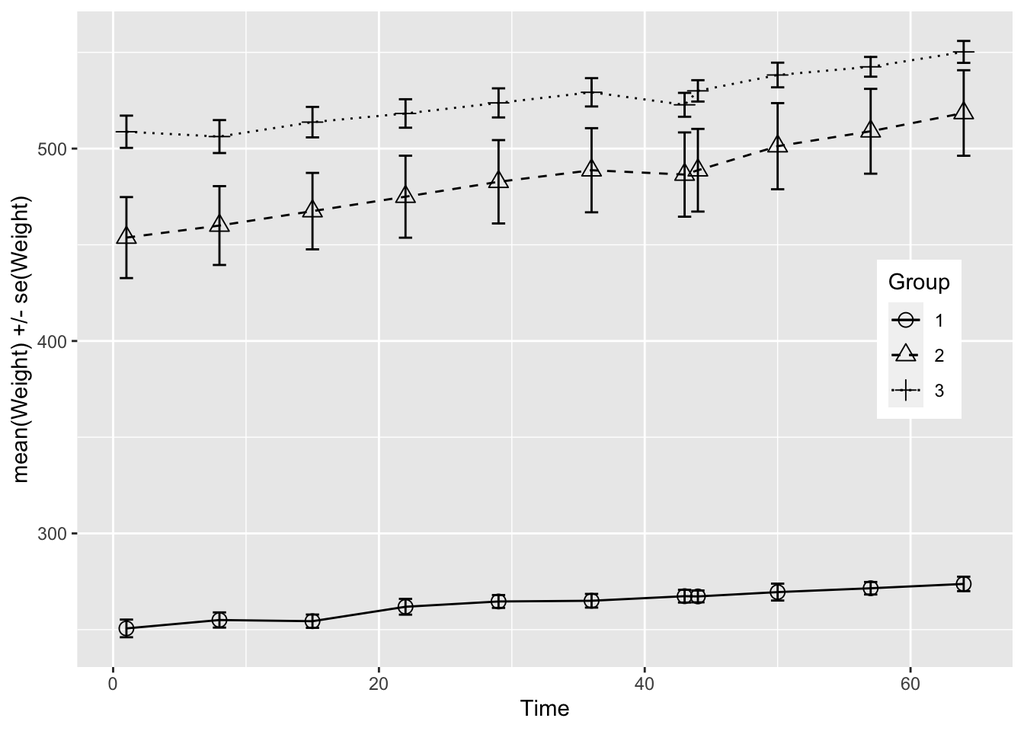

```r
# plot the mean profiles
ggplot(RATSLS, aes(x = Time, y = mean, linetype = Group, shape = Group)) +
  geom_line() +
  scale_linetype_manual(values = c(1,2,3)) +
  geom_point(size=3) +
  scale_shape_manual(values = c(1,2,3)) +
  geom_errorbar(aes(ymin = mean - se, ymax = mean + se, linetype="1"), width=1) +
  theme(legend.position = c(0.9,0.5)) +
  scale_y_continuous(name = "mean(Weight) +/- se(Weight)")
```

There’s no overlap in the mean profiles of the diet groups. The variance in groups 1 and 3 is very minor. Yhe variance is slightly bigger in group 2. It’s hard to tell based on this plot, if these three different diets have significally different responses on the rat growth.

The mean profiles can be also plotted with side-by-side box plots. The summary measure is the mean weight of days 1-64 on y-axis and the diet groups are on the x-axis.

```r
# create a summary data by group and ID with mean weight as the summary variable (ignore Time 0)
RATSL8S <- RATSL %>%
  filter(Time > 0) %>%
  group_by(Group, ID) %>%
  summarise( mean=mean(Weight) ) %>%
  ungroup()
# glimpse the data
glimpse(RATSL8S)
```

```
## Rows: 16
## Columns: 3
## $ Group <fct> 1, 1, 1, 1, 1, 1, 1, 1, 2, 2, 2, 2, 3, 3, 3, 3
## $ ID    <fct> 1, 2, 3, 4, 5, 6, 7, 8, 9, 10, 11, 12, 13, 14, 15, 16
## $ mean  <dbl> 261.0909, 237.6364, 260.1818, 266.5455, 269.4545, 274.7273, 274.…
```

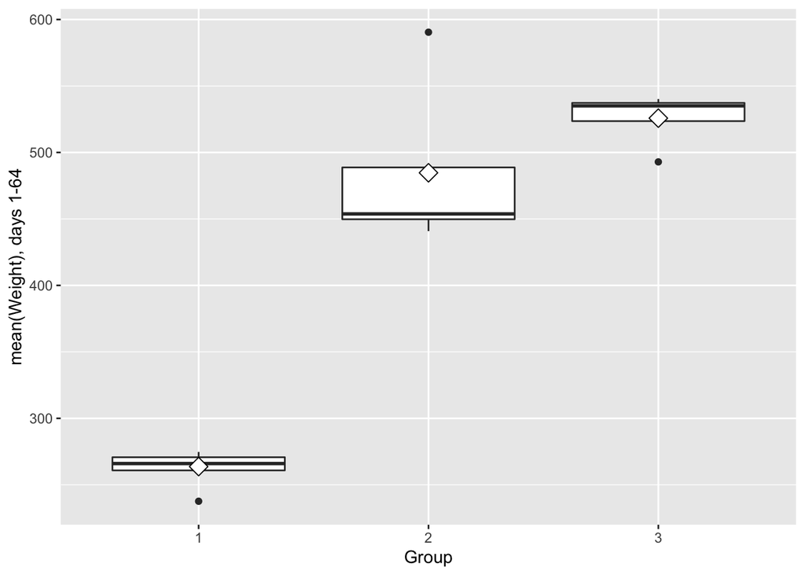

```r
# draw a boxplot of the mean versus group
ggplot(RATSL8S, aes(x = Group, y = mean)) +
  geom_boxplot() +
  stat_summary(fun = "mean", geom = "point", shape=23, size=4, fill = "white") +
  scale_y_continuous(name = "mean(Weight), days 1-64")
```

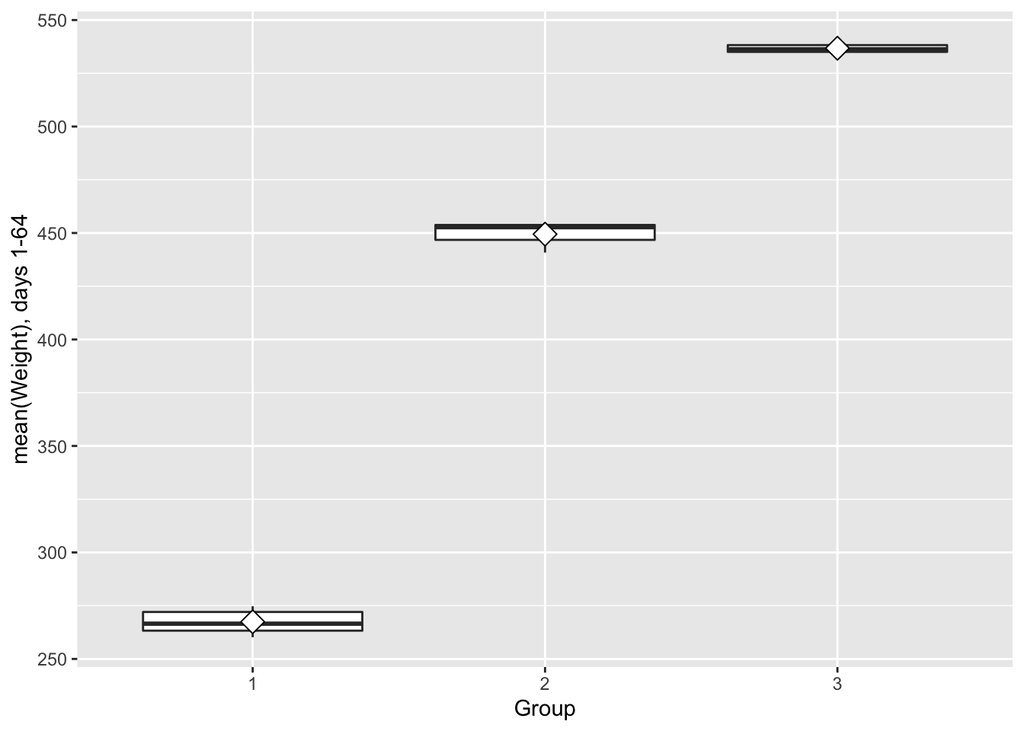

```r
# create a new data by filtering the outliers and adjust the ggplot code the draw the plot again with the new data
 RATSL8S1 <- RATSL8S %>%
 filter(mean < 550) %>% # outlier in group 2
 filter(mean > 250) # outlier in group 1
# remove outlier in group 3 from row 11
 RATSL8S1 <- RATSL8S1[-c(11),]

# draw a boxplot again without outliers
ggplot(RATSL8S1, mapping = aes(x = Group, y = mean)) +
  geom_boxplot() +
  stat_summary(fun = "mean", geom = "point", shape=23, size=4, fill = "white") +
  scale_y_continuous(name = "mean(Weight), days 1-64")
```

We can see three outliers, one for each group, in the first box plot. In the second box plot the outliers are removed in order to avoid bias in the futher comparisons of the groups. We can basically see the same things from the box plots than the ggplots above. There’s not a lot of variance and the groups are small.

Analysis of variance is done to investigate is there differencies between the means of three diet groups. We use the weight measured on day 1 as the baseline covariate.

```r
# read in original wide form RATS data to get the baseline
RATS <- read.table("https://raw.githubusercontent.com/KimmoVehkalahti/MABS/master/Examples/data/rats.txt", sep = '\t', header=T)
RATS$ID <- factor(RATS$ID)
RATS$Group <- factor(RATS$Group)

# Add the baseline from the original RATS data as a new variable to the summary data
RATSL8S2 <- RATSL8S %>%
  mutate(baseline = RATS$WD1)

# Fit the linear model with the mean as the response
fit <- lm(mean ~ baseline + Group, data = RATSL8S2)

# Compute the analysis of variance table for the fitted model with anova()
anova(fit)
```

```
## Analysis of Variance Table
##
## Response: mean
##           Df Sum Sq Mean Sq   F value    Pr(>F)
## baseline   1 252125  252125 2237.0655 5.217e-15 ***
## Group      2    726     363    3.2219   0.07586 .
## Residuals 12   1352     113
## ---
## Signif. codes:  0 '***' 0.001 '**' 0.01 '*' 0.05 '.' 0.1 ' ' 1
```

The baseline weight is strongly related to the weight measurements after the study began and there’s still no strong evidence of diet outcome differencies after conditioning on the baseline value.

### **2. Linear mixed effects models**

### **2.1 Structure of the longitudinal BPRSL data**

The original data is a study in which 40 male subjects were randomly assigned to one of two treatment groups and each subject was rated on the psychiatric rating scale (BPRS) measured before treatment began (week 0) and then weekly intervals for eight weeks.

BPRSL data has 360 observations (rows) and 6 variables (columns). The variables are treatment (1,2), subject (id 1-20 for both treatment groups), id (1-40, individual id), weeks (week0-week8), bprs (score 18-95) and week number (0-8). Each male has several rows of information, one row has information of one bprs measurement done in one time point. The treatment, subject and id variables are changed to factors.

```r
# read in BPRSL data
BPRSL <- read.csv('~/IODS-project/data/BPRSL.csv')

# check the data
glimpse(BPRSL)
```

```
## Rows: 360
## Columns: 6
## $ treatment <int> 1, 1, 1, 1, 1, 1, 1, 1, 1, 1, 1, 1, 1, 1, 1, 1, 1, 1, 1, 1, …
## $ subject   <int> 1, 2, 3, 4, 5, 6, 7, 8, 9, 10, 11, 12, 13, 14, 15, 16, 17, 1…
## $ id        <int> 1, 2, 3, 4, 5, 6, 7, 8, 9, 10, 11, 12, 13, 14, 15, 16, 17, 1…
## $ weeks     <chr> "week0", "week0", "week0", "week0", "week0", "week0", "week0…
## $ bprs      <int> 42, 58, 54, 55, 72, 48, 71, 30, 41, 57, 30, 55, 36, 38, 66, …
## $ week      <int> 0, 0, 0, 0, 0, 0, 0, 0, 0, 0, 0, 0, 0, 0, 0, 0, 0, 0, 0, 0, …
```

```r
# factor treatment & subject/id (convert the categorical variables to factors) of BPRS data
BPRSL$treatment <- factor(BPRSL$treatment)
BPRSL$subject <- factor(BPRSL$subject)
BPRSL$id <- factor(BPRSL$id)

# check the data
glimpse(BPRSL)
```

```
## Rows: 360
## Columns: 6
## $ treatment <fct> 1, 1, 1, 1, 1, 1, 1, 1, 1, 1, 1, 1, 1, 1, 1, 1, 1, 1, 1, 1, …
## $ subject   <fct> 1, 2, 3, 4, 5, 6, 7, 8, 9, 10, 11, 12, 13, 14, 15, 16, 17, 1…
## $ id        <fct> 1, 2, 3, 4, 5, 6, 7, 8, 9, 10, 11, 12, 13, 14, 15, 16, 17, 1…
## $ weeks     <chr> "week0", "week0", "week0", "week0", "week0", "week0", "week0…
## $ bprs      <int> 42, 58, 54, 55, 72, 48, 71, 30, 41, 57, 30, 55, 36, 38, 66, …
## $ week      <int> 0, 0, 0, 0, 0, 0, 0, 0, 0, 0, 0, 0, 0, 0, 0, 0, 0, 0, 0, 0, …
```

```r
head(BPRSL)
```

```
##   treatment subject id weeks bprs week
## 1         1       1  1 week0   42    0
## 2         1       2  2 week0   58    0
## 3         1       3  3 week0   54    0
## 4         1       4  4 week0   55    0
## 5         1       5  5 week0   72    0
## 6         1       6  6 week0   48    0
```

### **2.2 Graphics**

Let’s plot the observed values of the BPRSL data.

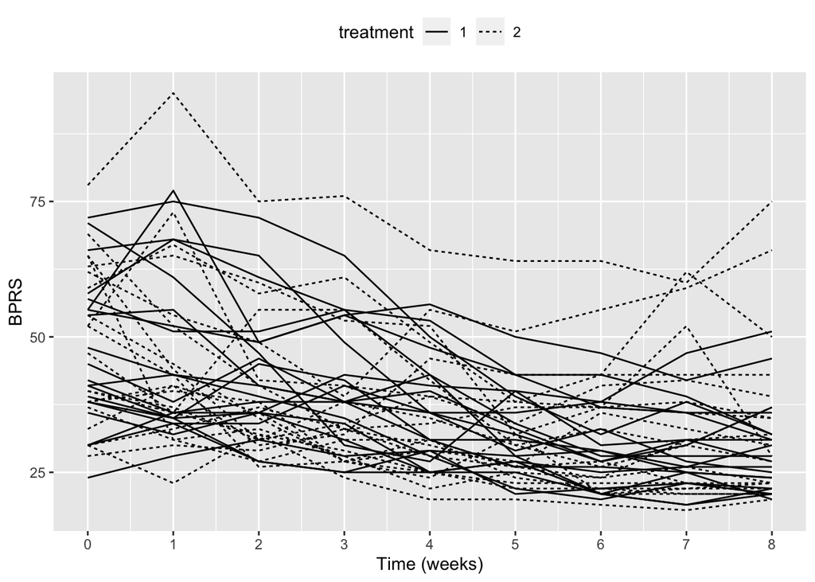

```r
# Plot the BPRSL data
ggplot(BPRSL, aes(x = week, y = bprs, group = id)) +
  geom_line(aes(linetype = treatment)) +
  scale_x_continuous(name = "Time (weeks)", breaks = seq(0, 8)) +
  scale_y_continuous(name = "BPRS") +
  theme(legend.position = "top")
```

The lines in the plot represent one individual, time in weeks is on the x-axis and the bprs is on the y-axis. Roughly it seems that the males’ bprs decrease over time but it’s difficult to be sure if it’s significant and you can’t distinguish the difference between the two treatments, based on this graph.

Let’s take a look at the mean bprs profiles with boxplots, the summary measure is the mean bprs of weeks 0-8 on y-axis and the treatment groups are on the x-axis.

```r
# create a summary data by treatment and id with mean bprs as the summary variable
  BPRSL8S <- BPRSL %>%
  group_by(treatment, id) %>%
  summarise( mean=mean(bprs) ) %>%
  ungroup()
```

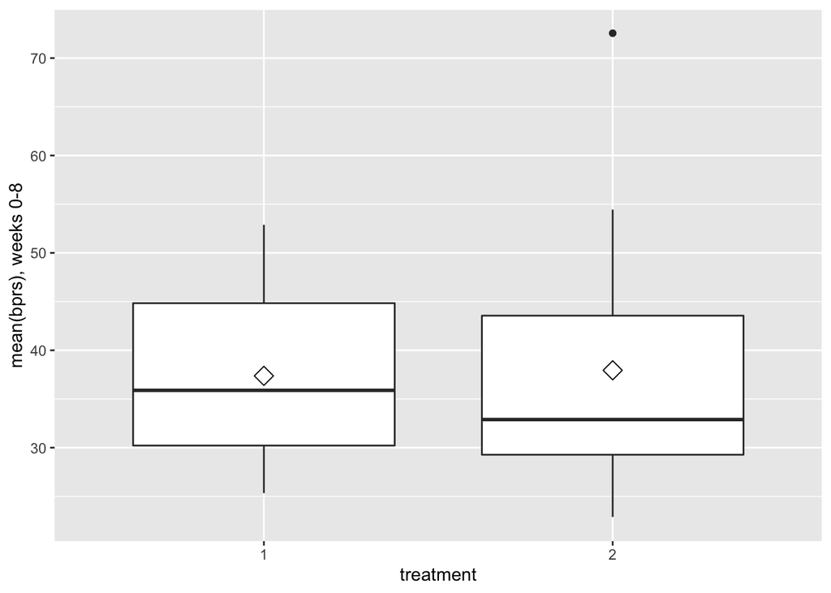

```r
# draw a boxplot of the mean bprs versus treatment
  ggplot(BPRSL8S, aes(x = treatment, y = mean)) +
  geom_boxplot() +
  stat_summary(fun = "mean", geom = "point", shape=23, size=4, fill = "white") +
  scale_y_continuous(name = "mean(bprs), weeks 0-8")
```

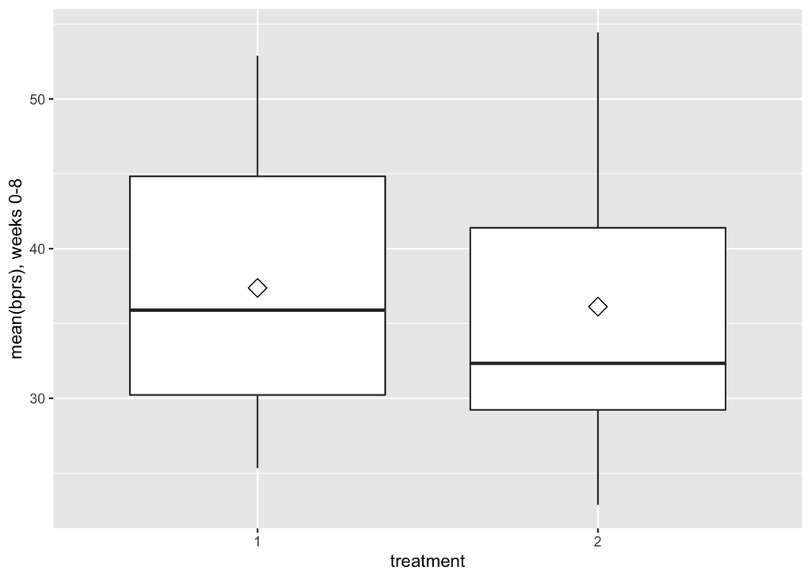

```r
# Create a new data by filtering the outlier and adjust the ggplot code the draw the plot again with the new data
  BPRSL8S1 <- BPRSL8S %>%
    filter(mean < 60)

# Draw a boxplot without the outlier
  ggplot(BPRSL8S1, aes(x = treatment, y = mean)) +
    geom_boxplot() +
    stat_summary(fun = "mean", geom = "point", shape=23, size=4, fill = "white") +
    scale_y_continuous(name = "mean(bprs), weeks 0-8")
```

In the second box plot the outlier is removed. Based on the box plot, it seems that there might not be significant difference between the means of these two treatment groups but further analysis would be needed to study the difference more closely.

### **2.3 Fitting the models**

Let’s fit a **multiple linear regression model** with bprs as response and week and treatment as explanatory variables.

```r
# create a regression model BPRS_reg
BPRS_reg <- lm(bprs ~ week + treatment, data = BPRSL)

# print out a summary of the model
summary(BPRS_reg)
```

```
##
## Call:
## lm(formula = bprs ~ week + treatment, data = BPRSL)
##
## Residuals:
##     Min      1Q  Median      3Q     Max
## -22.454  -8.965  -3.196   7.002  50.244
##
## Coefficients:
##             Estimate Std. Error t value Pr(>|t|)
## (Intercept)  46.4539     1.3670  33.982   <2e-16 ***
## week         -2.2704     0.2524  -8.995   <2e-16 ***
## treatment2    0.5722     1.3034   0.439    0.661
## ---
## Signif. codes:  0 '***' 0.001 '**' 0.01 '*' 0.05 '.' 0.1 ' ' 1
##
## Residual standard error: 12.37 on 357 degrees of freedom
## Multiple R-squared:  0.1851, Adjusted R-squared:  0.1806
## F-statistic: 40.55 on 2 and 357 DF,  p-value: < 2.2e-16
```

The linear model assumes independence of the repeated measures of bprs. The regression on week has a significant p-value <2e-16, the bprs score decreases over time. The treatment 2 has a non-significant p-value 0.661, there’s no difference between treatments.

Let’s fit **the random intercept model** for the same two explanatory variables. Fitting a random intercept model allows the linear regression fit for each individual to differ in intercept from other individuals. The lme4 package offers tools fo fitting linear and generalized linear mixed-effects models. In this model the male id is the random effect.

```r
# access library lme4
library(lme4)
# Create a random intercept model
BPRS_ref <- lmer(bprs ~ week + treatment + (1 | id), data = BPRSL, REML = FALSE)

# Print the summary of the model
summary(BPRS_ref)
```

```
## Linear mixed model fit by maximum likelihood  ['lmerMod']
## Formula: bprs ~ week + treatment + (1 | id)
##    Data: BPRSL
##
##      AIC      BIC   logLik deviance df.resid
##   2582.9   2602.3  -1286.5   2572.9      355
##
## Scaled residuals:
##      Min       1Q   Median       3Q      Max
## -2.27506 -0.59909 -0.06104  0.44226  3.15835
##
## Random effects:
##  Groups   Name        Variance Std.Dev.
##  id       (Intercept) 97.39    9.869
##  Residual             54.23    7.364
## Number of obs: 360, groups:  id, 40
##
## Fixed effects:
##             Estimate Std. Error t value
## (Intercept)  46.4539     2.3521  19.750
## week         -2.2704     0.1503 -15.104
## treatment2    0.5722     3.2159   0.178
##
## Correlation of Fixed Effects:
##            (Intr) week
## week       -0.256
## treatment2 -0.684  0.000
```

The estimated regression parameters for week and the treatment variables are similar to those from fitting the independence model shown in the multiple linear regression model. Random effect id variable has standard deviation of 9.869.

Let’s fit **random intercept and random slope model** to the BPRSL data. Fitting a random intercept and random slope model allows the linear regression fits for each individual to differ in intercept but also in slope. Now it is possible to account for the individual differences in the males’ bprs profiles, but also the effect of time.

```r
# create a random intercept and random slope model
BPRS_ref1 <- lmer(bprs ~ week + treatment + (week | id), data = BPRSL, REML = FALSE)

# print a summary of the model
summary(BPRS_ref1)
```

```
## Linear mixed model fit by maximum likelihood  ['lmerMod']
## Formula: bprs ~ week + treatment + (week | id)
##    Data: BPRSL
##
##      AIC      BIC   logLik deviance df.resid
##   2523.2   2550.4  -1254.6   2509.2      353
##
## Scaled residuals:
##     Min      1Q  Median      3Q     Max
## -2.4655 -0.5150 -0.0920  0.4347  3.7353
##
## Random effects:
##  Groups   Name        Variance Std.Dev. Corr
##  id       (Intercept) 167.827  12.955
##           week          2.331   1.527   -0.67
##  Residual              36.747   6.062
## Number of obs: 360, groups:  id, 40
##
## Fixed effects:
##             Estimate Std. Error t value
## (Intercept)  45.9830     2.6470  17.372
## week         -2.2704     0.2713  -8.370
## treatment2    1.5139     3.1392   0.482
##
## Correlation of Fixed Effects:
##            (Intr) week
## week       -0.545
## treatment2 -0.593  0.000
```

```r
# perform an ANOVA test on the two models
anova(BPRS_ref1, BPRS_ref)
```

```
## Data: BPRSL
## Models:
## BPRS_ref: bprs ~ week + treatment + (1 | id)
## BPRS_ref1: bprs ~ week + treatment + (week | id)
##           npar    AIC    BIC  logLik deviance  Chisq Df Pr(>Chisq)
## BPRS_ref     5 2582.9 2602.3 -1286.5   2572.9
## BPRS_ref1    7 2523.2 2550.4 -1254.6   2509.2 63.663  2  1.499e-14 ***
## ---
## Signif. codes:  0 '***' 0.001 '**' 0.01 '*' 0.05 '.' 0.1 ' ' 1
```

The likelyhood ratio test between BPRS_ref1 and BPRS_ref models shows a small p-value 1.499e-14 for BPRS_ref1 meaning that the random intercept and slope model provides a better fit to BPRSL data than the random intercept model.

Now let’s fit a **random intercept and slope model** that allows for a group × time **interaction**. The same model as above is used, week * treatment interaction is added.

```r
# create a random intercept and random slope model
BPRS_ref2 <- lmer(bprs ~ week * treatment + (week | id), data = BPRSL, REML = FALSE)

# print a summary of the model
summary(BPRS_ref2)
```

```
## Linear mixed model fit by maximum likelihood  ['lmerMod']
## Formula: bprs ~ week * treatment + (week | id)
##    Data: BPRSL
##
##      AIC      BIC   logLik deviance df.resid
##   2523.5   2554.5  -1253.7   2507.5      352
##
## Scaled residuals:
##     Min      1Q  Median      3Q     Max
## -2.4747 -0.5256 -0.0866  0.4435  3.7884
##
## Random effects:
##  Groups   Name        Variance Std.Dev. Corr
##  id       (Intercept) 164.204  12.814
##           week          2.203   1.484   -0.66
##  Residual              36.748   6.062
## Number of obs: 360, groups:  id, 40
##
## Fixed effects:
##                 Estimate Std. Error t value
## (Intercept)      47.8856     2.9840  16.047
## week             -2.6283     0.3752  -7.006
## treatment2       -2.2911     4.2200  -0.543
## week:treatment2   0.7158     0.5306   1.349
##
## Correlation of Fixed Effects:
##             (Intr) week   trtmn2
## week        -0.668
## treatment2  -0.707  0.473
## wek:trtmnt2  0.473 -0.707 -0.668
```

```r
# perform an ANOVA test on the two models
anova(BPRS_ref2, BPRS_ref1)
```

```
## Data: BPRSL
## Models:
## BPRS_ref1: bprs ~ week + treatment + (week | id)
## BPRS_ref2: bprs ~ week * treatment + (week | id)
##           npar    AIC    BIC  logLik deviance Chisq Df Pr(>Chisq)
## BPRS_ref1    7 2523.2 2550.4 -1254.6   2509.2
## BPRS_ref2    8 2523.5 2554.6 -1253.7   2507.5  1.78  1     0.1821
```

Above are the analysis of variance summaries and tables of the models BPRS_ref2 and BPRS_ref1. The likelyhood ratio test of the interaction random intercept and slope model against the corresponding model without an interaction shows a non-significant p-value of 0.1821 for BPRS_ref2. This means that the model without the interaction provides a better fit for the BPRSL data.

Let’s plot the fitted bprs values of each individual from the random intercept and random slope model (without the interaction. Below a vector of the fitted values of the model using the function fitted() is created. The plot shows fitted values of BPRSL data, weeks on the x-axis and fitted bprs on the y-axis.

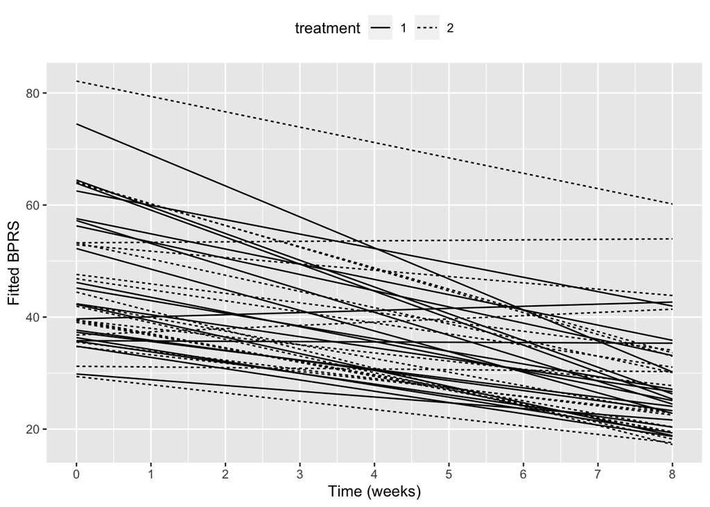

```r
# Create a vector of the fitted values
Fitted <- fitted(BPRS_ref1)

# Create a new column fitted to BPRSL
BPRSL <- BPRSL %>%
  mutate(Fitted)

# draw the plot of fitted BPRSL
ggplot(BPRSL, aes(x = week, y = Fitted, group = id)) +
  geom_line(aes(linetype = treatment)) +
  scale_x_continuous(name = "Time (weeks)", breaks = seq(0, 8)) +
  scale_y_continuous(name = "Fitted BPRS") +
  theme(legend.position = "top")
```